# Survey Data Processing, Validity,Reliability, and PCA for Student Satisfaction

Chloe Winters

April 13th 2025

# 1 Introduction

The goal of this research project is to look at student satisfaction, which can be a helpful tool in understanding students learning experience. This survey looks at identifying several of the factors that influence a students learning experience and outcomes. This survey contains several multi-item questions to asses the students satisfaction. Those questions cover the following categories, student engagement in learning, student learning styles, writing and reading load, remedial experience, encouragement and support, growth and development, campus resource utilization, retention and how students pay for college.

# 2 Materials

## 2.1 Data Preperation

The data set does originally load in will 664 observations where every other row is completely missing. From the information given regarding data collection we know that the size of the surveyed population was 334, and that participation was voluntary. This means that the NA rows are not missing observations and some data set loading error. Thus we are free to remove these rows. After doing so we are left with 332 observations. To see if any of the completed observations had any missing variables, code was run to check. None of the remaining observations had a single missing variable so there is no need for any data imputation or adjusting of the data set at this time.

```r
survey_missing = read.csv("https://chloewinters79.github.io/STA490/Data/at-risk-survey-data.csv", header = TRUE)
survey <- na.omit(survey_missing)
```

```r
missing_rows <- survey[apply(is.na(survey), 1, any), ]
print(missing_rows)
```

```
##   [1] q1      q2      q3      q41     q42     q43     q44     q45     q46
##  [10] q47     q48     q49     q410    q411    q412    q413    q414    q415
##  [19] q416    q417    q418    q419    q420    q421    q51     q52     q53
##  [28] q54     q55     q56     q61     q62     q63     q7      q81     q82
##  [37] q83     q84     q85     q86     q87     q88     q89     q91     q92
##  [46] q93     q94     q95     q96     q97     q101    q102    q103    q104
##  [55] q105    q106    q107    q108    q109    q1010   q1011   q1012   q1013
##  [64] q1014   q1015   q111.1  q111.2  q111.3  q112.1  q112.2  q112.3  q113.1
##  [73] q113.2  q113.3  q114.1  q114.2  q114.3  q115.1  q115.2  q115.3  q116.1
##  [82] q116.2  q116.3  q117.1  q117.2  q117.3  q118.1  q118.2  q118.3  q119.1
##  [91] q119.2  q119.3  q1110.1 q1110.2 q1110.3 q1111.1 q1111.2 q1111.3 q121
## [100] q122    q123    q124    q125    q131    q132    q133    q134    q135
## [109] q136    q14     q15     q16     q17     q18     q19     q20     q21
## [118] q22     q23     q24     q25
## <0 rows> (or 0-length row.names)
```

## 2.2 Validity and Reliability Analysis

Now that the data set has been loaded in and properly clean it is time to test for the validity and reliability of the survey instruments. There are several scales that are going to be analyzed to determine student satisfaction and they will be analyzed in the order they exist in the data set.

### 2.2.1 Students Engagement in Learning

The first section we are starting with is student engagement in learning, which asks students to answer questions on a 1 - 4 scale of very often to never regarding things they have done this current school year. This includes going to class without completing the reading, receiving prompt feedback, making a class presentation, and several other items. We start with a correlation plot to see the relevance on student engagement in learning on student satisfaction.

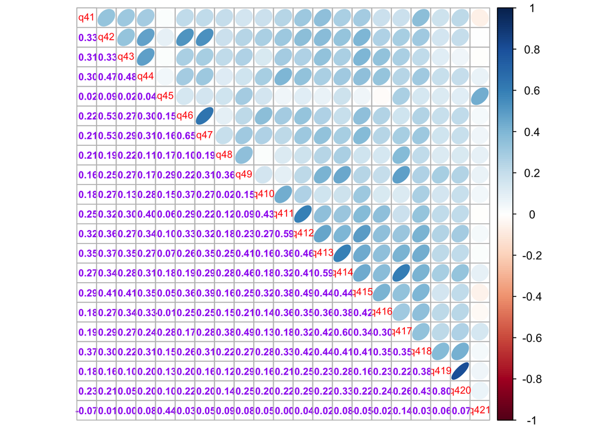

```r
start_col <- which(names(survey) == "q41")
end_col <- which(names(survey) == "q421")

engagement = survey[, start_col:end_col]

M=cor(engagement)
corrplot.mixed(M, lower.col = "purple", upper = "ellipse", number.cex = .7, tl.cex = 0.7)
```

Looking at the results there does appear to be potential relevance to student satisfaction, there was high correlation, shown by skinnier ellipse, in a few places on the pairwise correlation plot. However, a majority of the ellipse are much larger indicating a low correlation. In this plot, the larger ellipse far outweigh the skinnier ellipse, so while there may be potential relevance for a few of the questions asked regarding student engagement in learning, a majority of the questions do not depict potential relevance.

### 2.2.2 Student Learning Styles

The next section covers student learning styles, this asks students to answer questions on the 1 - 4 scale of very much to very little regarding mental activities emphasized in their coursework that year. These include memorizing facts and applying theories or concepts. A correlation plot was created to analyze the relevance on learning styles on students satisfaction.

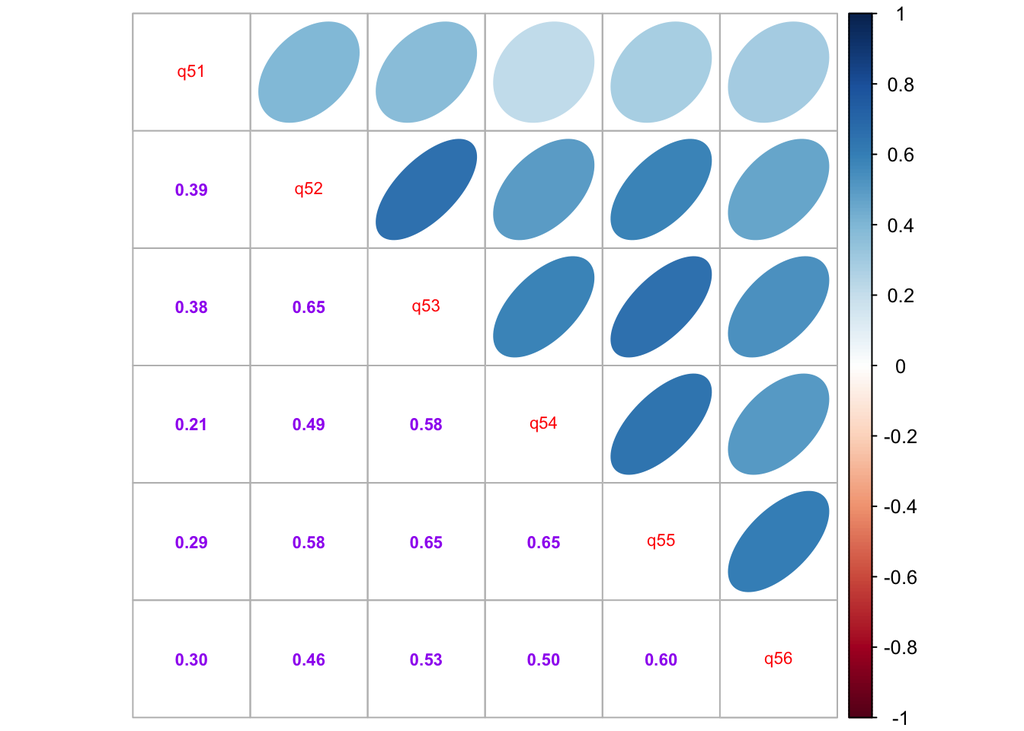

```r
start_col <- which(names(survey) == "q51")
end_col <- which(names(survey) == "q56")

learning = survey[, start_col:end_col]

M=cor(learning)
corrplot.mixed(M, lower.col = "purple", upper = "ellipse", number.cex = .7, tl.cex = 0.7)
```

Unlike the plot for students engagement, this correlation plot does not have the larger ellipse outweighing the skinnier ellipse. This plot supports high correlation between students learning styles and satisfaction, and a high potential relevance between the two variables.

### 2.2.3 Writing and Reading Load

This section focuses on how much writing and reading the students are doing during the current school year. It asks them to answer questions about number of assigned textbooks, books read for pleasure, and written papers required that year on a 1-5 scale from none to more than 20. A correlation plot was created to look at the relevance of writing and reading load on student satisfaction.

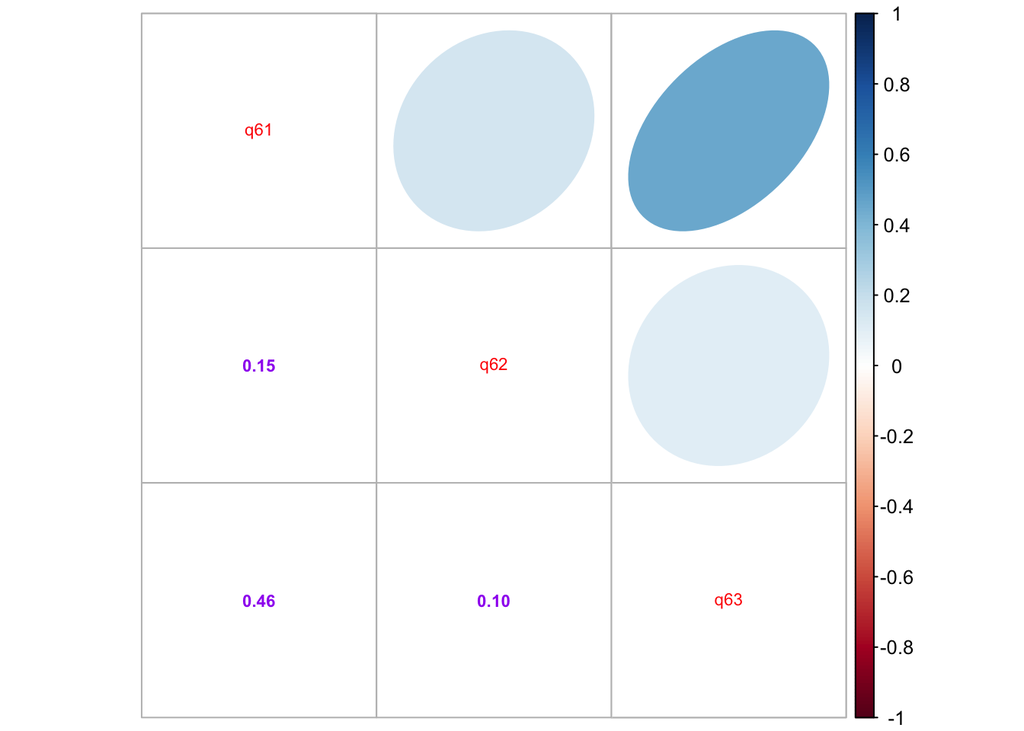

```r
start_col <- which(names(survey) == "q61")
end_col <- which(names(survey) == "q63")

writing = survey[, start_col:end_col]

M=cor(writing)
corrplot.mixed(M, lower.col = "purple", upper = "ellipse", number.cex = .7, tl.cex = 0.7)
```

This section is much shorter which results in a much shorter correlation plot. This makes it clear that the 3 ellipse are much larger, and do not support a high correlation between reading and writing load and student satisfaction, which does not support relevance.

### 2.2.4 Remedial Experience

The section on remedial experience asks students students to answer questions regarding things they plan on doing during their time attending the School of Businesses. These questions involve things like taking honors courses, internships, and college orientation programs. Students are asked to answer 1 for have done, 2 for plan to do, and 3 for have not done nor plan to. A correlation plot is created to examine potential relevance between remedial experience and student satisfaction.

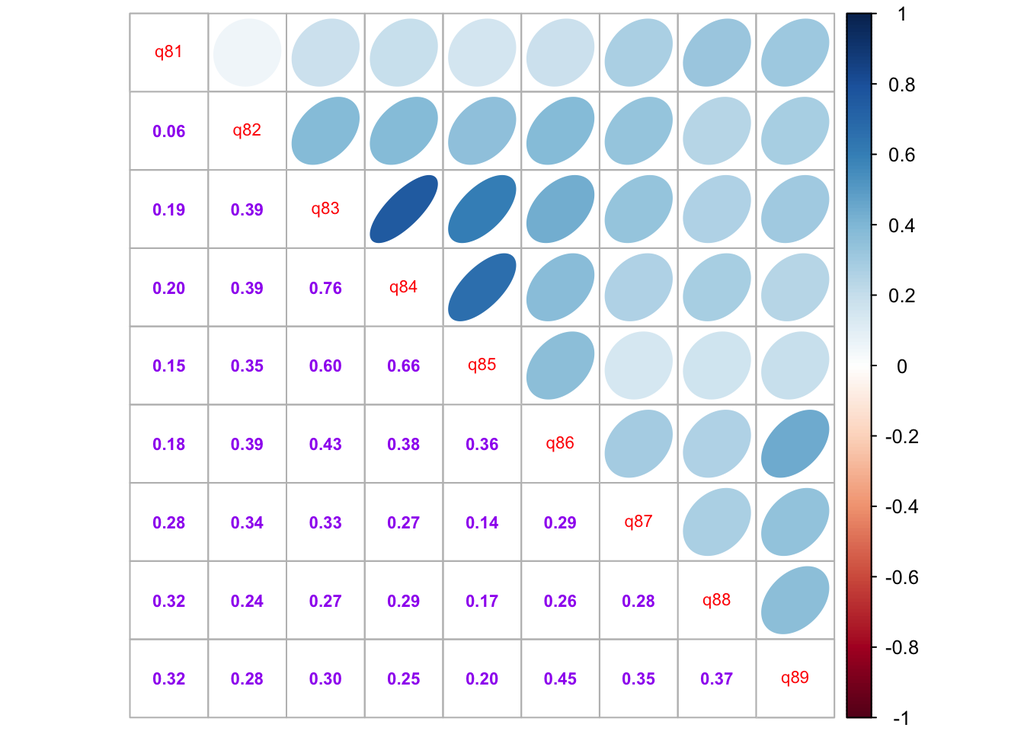

```r
start_col <- which(names(survey) == "q81")
end_col <- which(names(survey) == "q89")

remedial = survey[, start_col:end_col]

M=cor(remedial)
corrplot.mixed(M, lower.col = "purple", upper = "ellipse", number.cex = .7, tl.cex = 0.7)
```

Looking at remedial experience, there are 3 ellipse that are quite skinny and indicate a high correlation. However a majority of the ellipse are very large and showing a low correlation. This low correlation from a majority of the ellipse on the correlation plot does not support relevance between remedial experience and student satifaction.

### 2.2.5 Encouragement and Support

Encouragement and support focuses on seeing how much students believe the School of Business emphasizes things like spending time studying, thriving socially, and other things on a 1 - 4 scale of very much to very little. To examine the potential relevance between encouragement and support and student satisfaction we are going to analyze the below correlation plot.

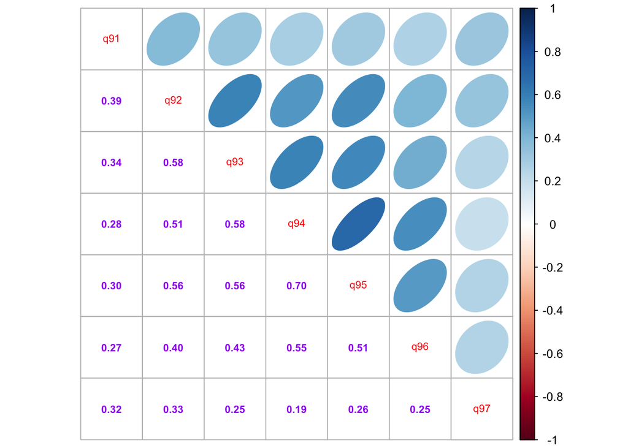

```r
start_col <- which(names(survey) == "q91")
end_col <- which(names(survey) == "q97")

encouragement = survey[, start_col:end_col]

M=cor(encouragement)
corrplot.mixed(M, lower.col = "purple", upper = "ellipse", number.cex = .7, tl.cex = 0.7)
```

The correlation for encouragement and support is quite interesting. It is a pretty even split of skinnier and larger ellipses. This makes it hard to determining where correlation and relevance really stands for encouragement and support and student satisfaction and more investigation might need to be made and possibly focusing on some questions in this section and not others.

### 2.2.6 Growth and Development

The growth and development section looks at seeing how students experience at the School of Business as contributed to their skills in areas like understanding themselves, solving numerical problems, working well with others, and much more. Again students are asked to answer on a 1 to 4 scale covering very much to very little. Another correlation plot will be created to analyze the potential relevance between growth and development and student satisfaction.

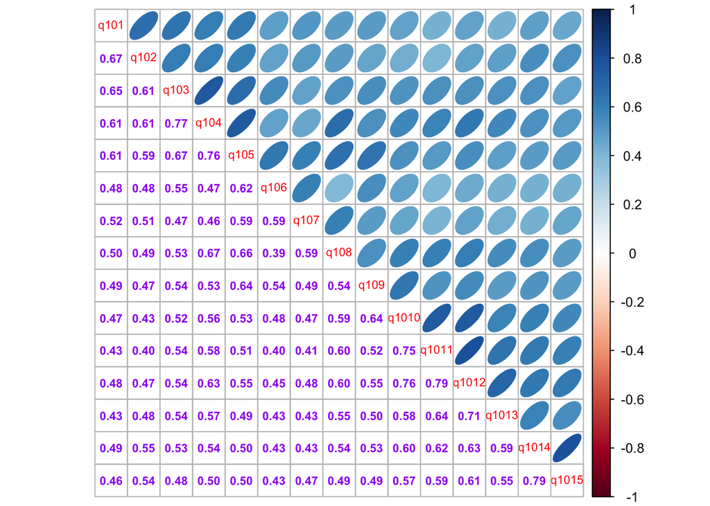

```r
start_col <- which(names(survey) == "q101")
end_col <- which(names(survey) == "q1015")

growth = survey[, start_col:end_col]

M=cor(growth)
corrplot.mixed(M, lower.col = "purple", upper = "ellipse", number.cex = .7, tl.cex = 0.7)
```

This correlation plot is on of the larger one, which makes it even more surprising that so many of the ellipses seems to have high correlation. This is great support for the relevance of all questions asked under growth and development when it comes to student satisfaction and this is definitely a variable that should be further analyzed in the next stage of analysis.

### 2.2.7 Campus Resource Utilization

This section regarding campus resource utilization is broken down into 3 sections which covers how often a student uses a service, how satisfied they are with it, and how important it is to them. Again students are asked to answer on the 1-4 scale of very much to very little for resources like skills labs, career counseling, and child care. The below correlation plot was created to determining any potential relevance between campus resource utilization and student satisfaction.

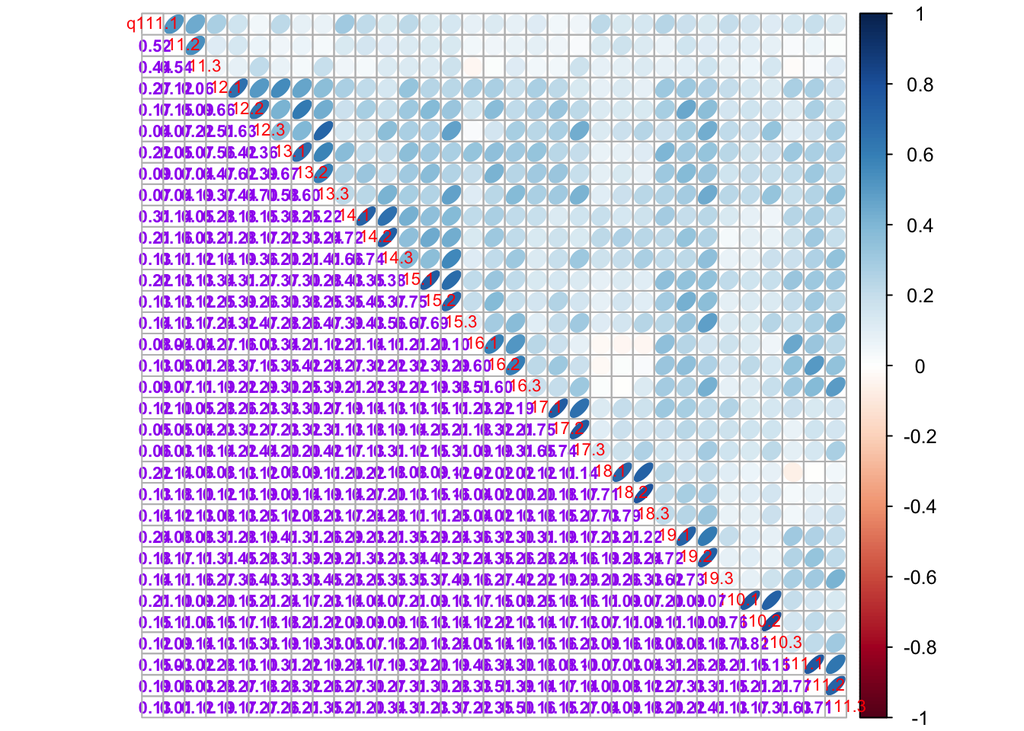

```r
start_col <- which(names(survey) == "q111.1")
end_col <- which(names(survey) == "q1111.3")

resource = survey[, start_col:end_col]


M=cor(resource)
corrplot.mixed(M, lower.col = "purple", upper = "ellipse", number.cex = .7, tl.cex = 0.7)
```

This section is another large correlation plot due to the three subsection in this section. While this correlation plot does show some highly correlated sections, a majority of them show a low correlation. With a majority of large ellipses indicating low correlation there is not much support for relevance between campus resources and student satisfaction. However, it may be worth looking into other ways to break down the subsections either by the specific resource and subsection questions to see if there is any relevance to be found in a smaller subsection.

### 2.2.8 Retention

Retention aims to understand what issues are likely of causing students to withdraw from school. Again answering on a 1-4 scale of very likely to not likely students are asked to answer how likely things like lack of finances and caring for dependents are at causing them to withdraw from school. The correlation plot below was analyzed to determining potential relevance between retention and student satisfaction.

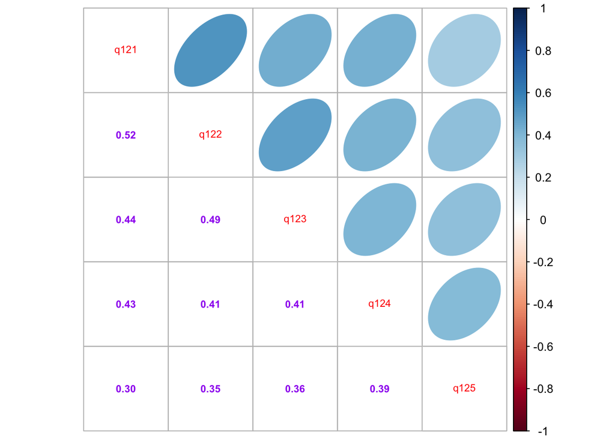

```r
start_col <- which(names(survey) == "q121")
end_col <- which(names(survey) == "q125")

retention = survey[, start_col:end_col]

M=cor(retention)
corrplot.mixed(M, lower.col = "purple", upper = "ellipse", number.cex = .7, tl.cex = 0.7)
```

Looking at the above correlation plot, all of the ellipses are much larger, indicating a lower correlation. This means there is not significant support of relevance between retention and student satisfaction. Considering the question this does make sense, it is asking for students to answer on the likelihood that things like financial hardship would cause them to leave school. If students are having financial hardships, they would typically have to leave school regardless of satisfaction so the lack of correlation is not surprising.

### 2.2.9 How Students Pay for College

The final section being analyzed for this survey is how students pay for college. Students are asked to indicate on a 1 to 3 scale being major source, minor source, and not a sources. Students are asked to rank thinks like grants, student loans, and public assistance on how much of a source they are in paying for tuition. A correlation plot was created to analyze potential relevance between how students pay for college and their satisfaction.

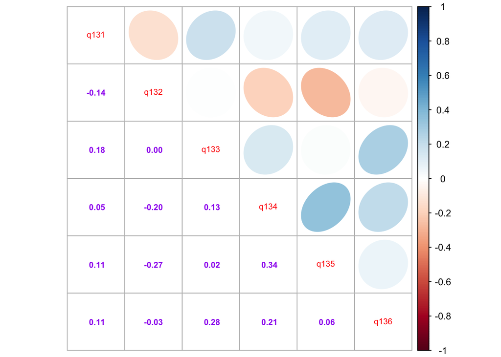

```r
start_col <- which(names(survey) == "q131")
end_col <- which(names(survey) == "q136")

payment = survey[, start_col:end_col]

M=cor(payment)
corrplot.mixed(M, lower.col = "purple", upper = "ellipse", number.cex = .7, tl.cex = 0.7)
```

## 2.3 PCA

After looking at all the recommended subsections for the student satisfaction survey for validity and reliability, it is time to conduct our principle component analysis (PCA). Since there were so many subsections analyzed for validity and reliability, we are going to use the results to select two subsections to conduct our PCA. The two best subsections from validity and reliability analysis was the Student Learning Styles, and Growth and Development sections. Any significant PCs found will be added to the analytic data set for the regression model.

The following two R functions are defined and used in the subsequent PCA.

```r
My.plotnScree = function(mat, legend = TRUE, method ="factors", main){
    ev <- eigen(cor(mat))
    ap <- parallel(subject=nrow(mat),var=ncol(mat), rep=5000,cent=.05)
    nScree = nScree(x=ev$values, aparallel=ap$eigen$qevpea, model=method)

    if (!inherits(nScree, "nScree"))
        stop("Method is only for nScree objects")
    if (nScree$Model == "components")
        nkaiser = "Eigenvalues > mean: n = "
    if (nScree$Model == "factors")
      nkaiser = "Eigenvalues > zero: n = "

    xlab = nScree$Model
    ylab = "Eigenvalues"

    par(col = 1, pch = 18)
    par(mfrow = c(1, 1))
    eig <- nScree$Analysis$Eigenvalues
    k <- 1:length(eig)
    plot(1:length(eig), eig, type="b", main = main,
        xlab = xlab, ylab = ylab, ylim=c(0, 1.2*max(eig)))

    nk <- length(eig)
    noc <- nScree$Components$noc
    vp.p <- lm(eig[c(noc + 1, nk)] ~ k[c(noc + 1, nk)])
    x <- sum(c(1, 1) * coef(vp.p))
    y <- sum(c(1, nk) * coef(vp.p))
    par(col = 10)
    lines(k[c(1, nk)], c(x, y))
    par(col = 11, pch = 20)
    lines(1:nk, nScree$Analysis$Par.Analysis, type = "b")
    if (legend == TRUE) {
        leg.txt <- c(paste(nkaiser, nScree$Components$nkaiser),
                   c(paste("Parallel Analysis: n = ", nScree$Components$nparallel)),
                   c(paste("Optimal Coordinates: n = ", nScree$Components$noc)),
                   c(paste("Acceleration Factor: n = ", nScree$Components$naf))
                   )
        legend("topright", legend = leg.txt, pch = c(18, 20, NA, NA),
                           text.col = c(1, 3, 2, 4),
                           col = c(1, 3, 2, 4), bty="n", cex=0.7)
    }
    naf <- nScree$Components$naf
    text(x = noc, y = eig[noc], label = " (OC)", cex = 0.7,
        adj = c(0, 0), col = 2)
    text(x = naf + 1, y = eig[naf + 1], label = " (AF)",
        cex = 0.7, adj = c(0, 0), col = 4)
}
```

```r
My.loadings.var <- function(mat, nfct, method="fa"){
    if(method == "fa"){
     f1 <- factanal(mat, factors = nfct,  rotation = "varimax")
     x <- loadings(f1)
     vx <- colSums(x^2)
     varSS = rbind('SS loadings' = vx,
            'Proportion Var' = vx/nrow(x),
           'Cumulative Var' = cumsum(vx/nrow(x)))
     weight = f1$loadings[]
   } else if (method == "pca"){
     pca <- prcomp(mat, center = TRUE, scale = TRUE)
     varSS = summary(pca)$importance[,1:nfct]
     weight = pca$rotation[,1:nfct]
  }
    list(Loadings = weight, Prop.Var = varSS)
}
```

## 2.4 PCA Extraction and Number of PCA Determination: Student Learning Methods

The total number of PCAs selected for further analysis is very important and needs to be addressed before moving on with further PC analysis. For the purpose of exploration and further investigation the first two pcs from PCA and EFA will be chosen and used for association analysis.

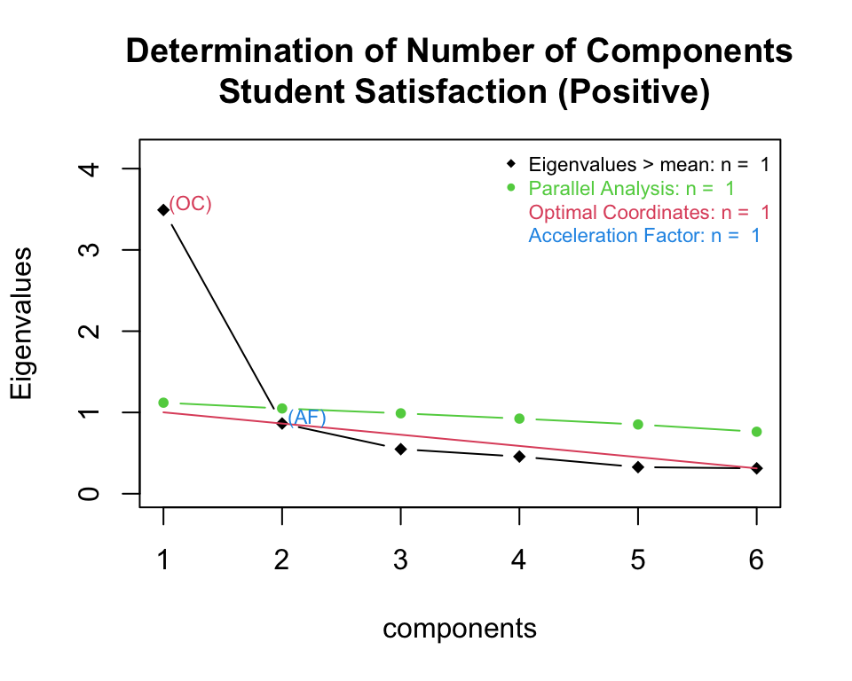

```r
My.plotnScree(mat=learning, legend = TRUE, method ="components",
              main="Determination of Number of Components\n Student Satisfaction (Positive)")
```

Examining the figure above, it appears that retaining the first principle components is sufficient.

Below, the first two PCAs have been extracted, and the PCA factor loading and proportion of variance explained by the retained is summarized in the tables.

```r
Loadings = My.loadings.var(mat=learning, nfct=2, method="pca")$Loadings

kable(round(Loadings,3),
  caption="Factor loadings of the first few PCAs and the cumulative proportion
of variation explained by the corresponding PCAs in the student satisfaction survey.")
```

Factor loadings of the first few PCAs and the cumulative proportion of variation explained by the corresponding PCAs in the student satisfaction survey.

|  | PC1 | PC2 |
| --- | --- | --- |
| q51 | 0.272 | -0.881 |
| q52 | 0.424 | -0.147 |
| q53 | 0.455 | -0.014 |
| q54 | 0.413 | 0.362 |
| q55 | 0.455 | 0.229 |
| q56 | 0.403 | 0.135 |

```r
VarProp = My.loadings.var(mat=learning, nfct=2, method="pca")$Prop.Var

kable(round(VarProp,3),
    caption="Cumulative and proportion of variances explained by each
    the principal component in the student satisfaction survey.")
```

Cumulative and proportion of variances explained by each the principal component in the student satisfaction survey.

|  | PC1 | PC2 |
| --- | --- | --- |
| Standard deviation | 1.868 | 0.929 |
| Proportion of Variance | 0.582 | 0.144 |
| Cumulative Proportion | 0.582 | 0.726 |

The student learning styles index is extracted by the below code.

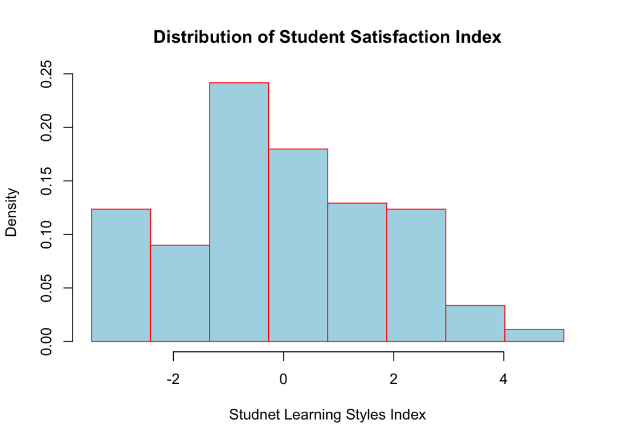

```r
pca <- prcomp(learning, center = TRUE, scale = TRUE)
sc.idx = pca$x[,1]
hist(sc.idx,
main="Distribution of Student Satisfaction Index",
breaks = seq(min(sc.idx), max(sc.idx), length=9),
xlab="Studnet Learning Styles Index",
xlim=range(sc.idx),
border="red",
col="lightblue",
freq=FALSE
)
```

Histogram of the first principle component extract from the student satisfaction survey.

### 2.4.1 Growth And Development

As mentioned earlier in the student learning section, total number of PCAs selected for further analysis is very important and needs to be addressed before moving on with further PC analysis. Just like in the exploration used for student learning styles, for growth and development, the first two pcs from PCA and EFA will be chosen and used for association analysis.

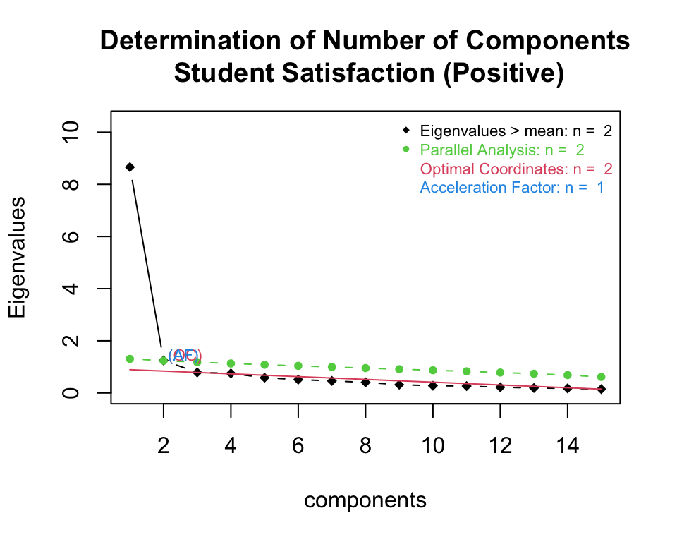

```r
My.plotnScree(mat=growth, legend = TRUE, method ="components",
              main="Determination of Number of Components\n Student Satisfaction (Positive)")
```

In the following code below, the first two PCAs have been extracted. In addition, the PCA factor loading and proportion of variance explained by the retained is summarized in the tables.

```r
Loadings = My.loadings.var(mat=growth, nfct=2, method="pca")$Loadings

kable(round(Loadings,3),
  caption="Factor loadings of the first few PCAs and the cumulative proportion
of variation explained by the corresponding PCAs in the student satisfaction survey.")
```

Factor loadings of the first few PCAs and the cumulative proportion of variation explained by the corresponding PCAs in the student satisfaction survey.

|  | PC1 | PC2 |
| --- | --- | --- |
| q101 | -0.246 | 0.327 |
| q102 | -0.246 | 0.282 |
| q103 | -0.267 | 0.231 |
| q104 | -0.278 | 0.138 |
| q105 | -0.275 | 0.289 |
| q106 | -0.229 | 0.284 |
| q107 | -0.234 | 0.244 |
| q108 | -0.262 | -0.017 |
| q109 | -0.253 | 0.031 |
| q1010 | -0.268 | -0.285 |
| q1011 | -0.264 | -0.389 |
| q1012 | -0.277 | -0.334 |
| q1013 | -0.254 | -0.251 |
| q1014 | -0.262 | -0.241 |
| q1015 | -0.252 | -0.225 |

```r
VarProp = My.loadings.var(mat=growth, nfct=2, method="pca")$Prop.Var
kable(round(VarProp,3),
    caption="Cumulative and proportion of variances explained by each
    the principal component in the student satisfaction survey.")
```

Cumulative and proportion of variances explained by each the principal component in the student satisfaction survey.

|  | PC1 | PC2 |
| --- | --- | --- |
| Standard deviation | 2.943 | 1.117 |
| Proportion of Variance | 0.577 | 0.083 |
| Cumulative Proportion | 0.577 | 0.661 |

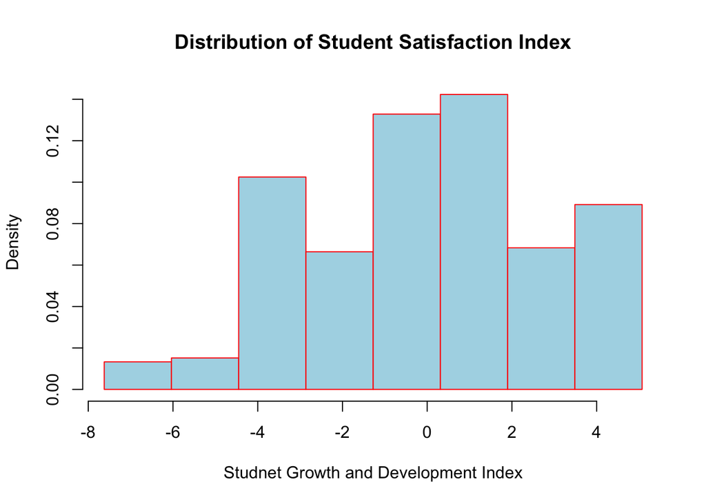

```r
pca <- prcomp(growth, center = TRUE, scale = TRUE)
sc.idx = pca$x[,1]

hist(sc.idx,
main="Distribution of Student Satisfaction Index",
breaks = seq(min(sc.idx), max(sc.idx), length=9),
xlab="Studnet Growth and Development Index",
xlim=range(sc.idx),
border="red",
col="lightblue",
freq=FALSE
)
```

Histogram of the first principle component extract from the student satisfaction survey.

# 3 Project Questions

Now that the we have looked further into PCA for the two strongest subsections showing in the validity and reliability section of the analysis, the project questions can be developed even further. In this section we conducted further analysis on the growth and development section and saw that unequal proportion of the variation between the first and second principle components. Looking further into this in our future analysis could be incredibly beneficial. Additionally, pairing this with the sub grouping with different student populations like race, gender, and class, could possibly produce some interesting results that could better inform the school on how to best serve their students.

For another question, while not originally proposed as something to investigate in the previous report, even further analysis on student learning styles could be incredibly beneficial to the school. Despite being a smaller category it has produced some great results in preliminary analysis for validity and reliability along with PCA. The output so far is very promising and continuing the analysis of this subsection could yield some really incredible results for the school and benefit the students and increase their satisfaction.